# Incidents Responded to Across the City of Austin

## Annie Fu (UT EID: arf2742)

### Introduction

This report will be an extension of the last report by only focusing on one data set (the number of incidents that were responded to) from the public database that the City of Austin provides (https://data.austintexas.gov/). Interest was sparked to continue to explore this dataset as it was found that there were a a lot of months that didn’t meat compliance requirements, meaning that a lot of ambulances didn’t arrive quick enough.

Each row for this dataset represents an observation made in a month of a specific year from October 2010 to January 2023. The variables that the Incidents dataset contains are `Month.Key` (formatted YYYYMM), `Month.Year` (formatted MON YEAR), `Total.Incidents` (the total number of incidents responded to), `Austin.Incidents` (the total number of incidents in the city of Austin), `Travis.County.Incidents` (the total number of incidents in Travis County), `Other.Area.Incidents` (the total number of incidents not in the city of Austin or Travis County), `Combined.Austin.and.Travis.County.Incidents` (the total combined number of incidents in the city of Austin and Travis County), `Austin.P1.Incidents` ~ `Austin.P5.Incidents` (the total number of incidents based on priority level in the city of Austin where P1 is the most sever and P5 is the least), `Travis.County.P1.Incidents` ~ `Travis.County.P5.Incidents` (the total number of incidents based on priority level in Travis County), `Overall.On.Time.Compliance` (the percentage of ambulances that arrived on time in all of Austin), `Austin.On.Time.Compliance` (the percentage of ambulances that arrived on time in the city of Austin), `Travis.County.On.Time.Compliance` (the percentage of ambulances that arrived on time in Travis County), `Austin.P1.On.Time.Compliance` ~ `Austin.P5.On.Time.Compliance` (the percentage of ambulances that arrived on time depending on priority level in the city of Austin), `Travis.County.P1.On.Time.Compliance` ~ `Travis.County.P5.On.Time.Compliance` (the percentage of ambulances that arrived on time depending on the priority levels in Travis County), and `Target.On.Time.Compliance` (the target percentage of ambulances that should arrive on time).

Due to the many different variables, a lot of different potential relationships can be explored: how location can impact the number of ambulances sent out, whether priority level incidents may be affected by location, or whether the number of incidents a city has affects how quickly an ambulance can arrive.

Considering all of the potential relationships that can be explored, the following question was crafted: *How well does the year (Year), the priority level of patients (Priority), and the total number of incidents for those priority levels (Incidents) predict whether or not the target compliance was met for a particular month of a year?*

It’s predicted that these three variables may be good predictors of the target compliance. It may be seen that the higher the number of incidents for any priority level that have been answered to, the less likely that target compliance was met (same with the the increase in severity of priority level and increase in years).

```r
# load packages
library(tidyverse)
library(plotROC)
library(caret)
library(ggcorrplot)
library(cluster)
library(factoextra)

# Save the data as a dataframe
incidents <- read.csv("incidents.csv")
```

### Tidying/Wrangling of Incidents Dataset

Before the Incidents dataset can be tidied/wrangled, the observations for the separate location priority levels (Austin and Travis County) had to be combined. The incidents were added together while the compliances were recalculated with the following equation:
$$\frac{COA.Priority.Comp/100 *
COA.Priority.Incidents + TC.Priority.Comp/100 *
TC.Priority.Incidents}{Total.COA.and.TC.Priority.Incidents}$$
Furthermore, all of the individual columns of the priority levels (such as `Austin.P1.Incidents`) were removed.

```r
#recalculate priority level incidents and compliances
incidents1 <- incidents %>%
  #combine the priority level incidents
  mutate("P1.Incidents" = Travis.County.P1.Incidents + Austin.P1.Incidents,
         "P2.Incidents" = Travis.County.P2.Incidents + Austin.P2.Incidents,
         "P3.Incidents" = Travis.County.P3.Incidents + Austin.P3.Incidents,
         "P4.Incidents" = Travis.County.P4.Incidents + Austin.P4.Incidents,
         "P5.Incidents" = Travis.County.P5.Incidents + Austin.P5.Incidents,
         #find total compliances of each priority level
         "P1.Compliance" = 100 * (Austin.P1.On.Time.Compliance/100 * Austin.P1.Incidents + Travis.County.P1.On.Time.Compliance/100 * Travis.County.P1.Incidents)/P1.Incidents,
         "P2.Compliance" = 100 * (Austin.P2.On.Time.Compliance/100 * Austin.P2.Incidents + Travis.County.P2.On.Time.Compliance/100 * Travis.County.P2.Incidents)/P2.Incidents,
         "P3.Compliance" = 100 * (Austin.P3.On.Time.Compliance/100 * Austin.P3.Incidents + Travis.County.P3.On.Time.Compliance/100 * Travis.County.P3.Incidents)/P3.Incidents,
         "P4.Compliance" = 100 * (Austin.P4.On.Time.Compliance/100 * Austin.P4.Incidents + Travis.County.P4.On.Time.Compliance/100 * Travis.County.P4.Incidents)/P4.Incidents,
         "P5.Compliance" = 100 * (Austin.P5.On.Time.Compliance/100 * Austin.P5.Incidents + Travis.County.P5.On.Time.Compliance/100 * Travis.County.P5.Incidents)/P5.Incidents) %>%
  #remove the individual incidents and compliance counts
  select(-c("Austin.P1.Incidents":"Travis.County.P5.Incidents"), -c("Austin.P1.On.Time.Compliance":"Travis.County.P5.On.Time.Compliance"))

incidents1
```

```
##   Month.Key Month.Year Total.Incidents Austin.Incidents Travis.County.Incidents
## 1    201010   Oct 2010            8910             7571                    1321
## 2    201011   Nov 2010            7826             6564                    1232
## 3    201012   Dec 2010            8182             6858                    1290
## 4    201101   Jan 2011            8287             7081                    1185
##   Other.Area.Incidents Combined.Austin.and.Travis.County.Incidents
## 1                   18                                        8892
## 2                   30                                        7796
## 3                   34                                        8148
## 4                   21                                        8266
##   Overall.On.Time.Compliance Austin.On.Time.Compliance
## 1                      95.77                     97.32
## 2                      96.01                     97.23
## 3                      95.45                     96.88
## 4                      95.92                     97.13
```

[output cut: 16 more lines]

Then, to tidy the dataset, the `pivot_longer()` was used to combine all of the necessary columns into the format of `priority.type` with their values. `separate()` was then used to split the `priority.type` column into `Priority` (the priority level of the incidents) and `Type` (whether it was incidents or compliance) and to split the `Month.Year` column into `Month` and `Year`.

```r
#condense columns into one
incidents1 <- incidents1 %>%
  #create priority and type columns
  pivot_longer(cols = c("P1.Incidents":"P5.Compliance"),
               names_to = "priority.type",
               values_to = "Count") %>%
  separate(priority.type,
           into = c( "Priority", "Type"),
           convert = TRUE) %>%
  #create month and year columns
  separate(Month.Year,
           into = c( "Month", "Year"),
           convert = TRUE)
incidents1
```

```
## # A tibble: 1,480 × 15
##    Month.Key Month  Year Total…¹ Austi…² Travi…³ Other…⁴ Combi…⁵ Overa…⁶ Austi…⁷
##        <int> <chr> <int>   <int>   <int>   <int>   <int>   <int>   <dbl>   <dbl>
##  1    201010 Oct    2010    8910    7571    1321      18    8892    95.8    97.3
##  2    201010 Oct    2010    8910    7571    1321      18    8892    95.8    97.3
##  3    201010 Oct    2010    8910    7571    1321      18    8892    95.8    97.3
##  4    201010 Oct    2010    8910    7571    1321      18    8892    95.8    97.3
##  5    201010 Oct    2010    8910    7571    1321      18    8892    95.8    97.3
##  6    201010 Oct    2010    8910    7571    1321      18    8892    95.8    97.3
##  7    201010 Oct    2010    8910    7571    1321      18    8892    95.8    97.3
##  8    201010 Oct    2010    8910    7571    1321      18    8892    95.8    97.3
##  9    201010 Oct    2010    8910    7571    1321      18    8892    95.8    97.3
## 10    201010 Oct    2010    8910    7571    1321      18    8892    95.8    97.3
## # … with 1,470 more rows, 5 more variables:
## #   Travis.County.On.Time.Compliance <dbl>, Target.On.Time.Compliance <int>,
## #   Priority <chr>, Type <chr>, Count <dbl>, and abbreviated variable names
## #   ¹Total.Incidents, ²Austin.Incidents, ³Travis.County.Incidents,
## #   ⁴Other.Area.Incidents, ⁵Combined.Austin.and.Travis.County.Incidents,
## #   ⁶Overall.On.Time.Compliance, ⁷Austin.On.Time.Compliance
```

The `pivot_wider` column was used to separate `Incidents` and `Complaince` to create the final tidy dataset of `incidents1`.

```r
#make incidents and compliance into separate variables
incidents1 <- incidents1 %>%
  pivot_wider(names_from = Type,
              values_from = Count)

incidents1
```

```
## # A tibble: 740 × 15
##    Month.Key Month  Year Total…¹ Austi…² Travi…³ Other…⁴ Combi…⁵ Overa…⁶ Austi…⁷
##        <int> <chr> <int>   <int>   <int>   <int>   <int>   <int>   <dbl>   <dbl>
##  1    201010 Oct    2010    8910    7571    1321      18    8892    95.8    97.3
##  2    201010 Oct    2010    8910    7571    1321      18    8892    95.8    97.3
##  3    201010 Oct    2010    8910    7571    1321      18    8892    95.8    97.3
##  4    201010 Oct    2010    8910    7571    1321      18    8892    95.8    97.3
##  5    201010 Oct    2010    8910    7571    1321      18    8892    95.8    97.3
##  6    201011 Nov    2010    7826    6564    1232      30    7796    96.0    97.2
##  7    201011 Nov    2010    7826    6564    1232      30    7796    96.0    97.2
##  8    201011 Nov    2010    7826    6564    1232      30    7796    96.0    97.2
##  9    201011 Nov    2010    7826    6564    1232      30    7796    96.0    97.2
## 10    201011 Nov    2010    7826    6564    1232      30    7796    96.0    97.2
## # … with 730 more rows, 5 more variables:
## #   Travis.County.On.Time.Compliance <dbl>, Target.On.Time.Compliance <int>,
## #   Priority <chr>, Incidents <dbl>, Compliance <dbl>, and abbreviated variable
## #   names ¹Total.Incidents, ²Austin.Incidents, ³Travis.County.Incidents,
## #   ⁴Other.Area.Incidents, ⁵Combined.Austin.and.Travis.County.Incidents,
## #   ⁶Overall.On.Time.Compliance, ⁷Austin.On.Time.Compliance
```

### Exploratory Data Analysis

Before any data exploration could be done, the `Priority` column had to be mutated from a character class type to a numeric value (i.e. P1 = 1).

```r
#manipulate outcome variable and character variables into values
incidents1 %>%
  mutate(Priority = case_when(Priority == "P1" ~ 1,
                              Priority == "P2" ~ 2,
                              Priority == "P3" ~ 3,
                              Priority == "P4" ~ 4,
                              Priority == "P5" ~ 5)) -> incidents1
```

A correlation matrix was then created to see which pairs of variables are the most/least correlated out of the variables that are being explored in this report (`Year`, `Incidents`, `Priority`, and `Compliance`).

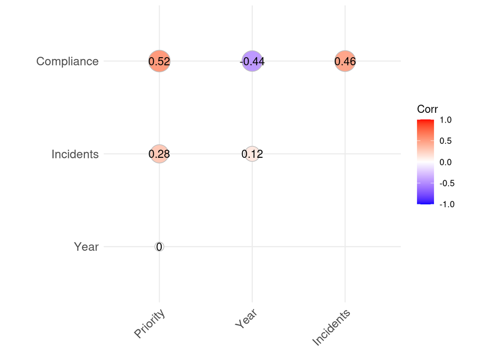

```r
#correlation matrix of incidents1
ggcorrplot(cor(incidents1 %>%
                 select(Priority, Year, Incidents, Compliance)),
           type = "upper", # upper diagonal
           lab = TRUE, # print values
           method = "circle")
```

The pair of variables that had the greatest correlation was Compliance and Priority with the largest correlation magnitude value (0.52). The least correlated pair of variables is Year and Priority with the smallest correaltion magnitude value (0). This makes sense since there were emergencies for each priority level every year meaning that there would be no relationship between the two variables whereas there could be very different compliance levels among priority levels since a late ambulance for different priority levels could mean life or death of a patient.

Furthermore, visualizations were made to observe the relationship between each predictor variable compared to the outcome variable.

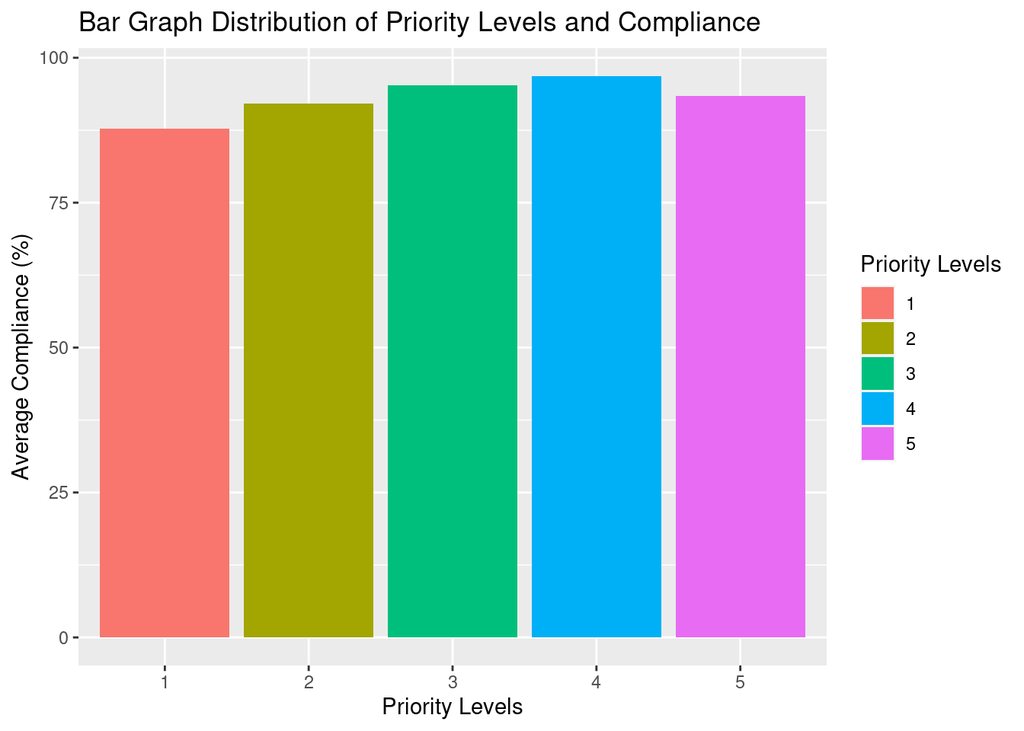

```r
#bar graph of average compliance for each priority level
ggplot(incidents1, aes(x = as.character(Priority), y = Compliance, fill = as.character(Priority))) +
  geom_bar(stat = "summary", fun = "mean") +
  labs(title = "Bar Graph Distribution of Priority Levels and Compliance",
       x = "Priority Levels",
       y = "Average Compliance (%)",
       fill = "Priority Levels")
```

This visualization is of a bar graph comparing the average compliance percentages of each of the priority levels. Based on the graph, there seems to be a trend that as the severity of the priority level decreases (where priority level 5 is less severe compared to priority level 1) as the average compliance percentage increases from left to right (with the exception of priority level 5). Thus, there is some negative correlation between the priority levels and compliance (in terms of severity of the patient vs compliance; otherwise, there is a positive correlation between the numeric values of the priority level and compliance).

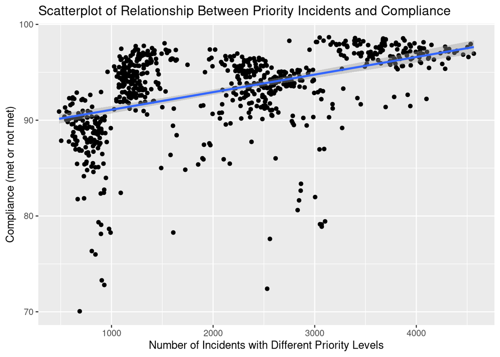

```r
#scatterplot of priority incidents with compliance
ggplot(incidents1, aes(x = Incidents, y = Compliance)) +
  geom_point() +
  geom_smooth(method = "lm") +
  labs(title = "Scatterplot of Relationship Between Priority Incidents and Compliance",
       x = "Number of Incidents with Different Priority Levels",
       y = "Compliance (met or not met)")
```

This visualization depicts the relationship between the the number of incidents with the different priority levels within a month and their compliance. It confirms that there is a positive correlation between the priority incidents and compliance percentage that the correlation matrix demonstrated as there is a positive trend shown by the blue line.

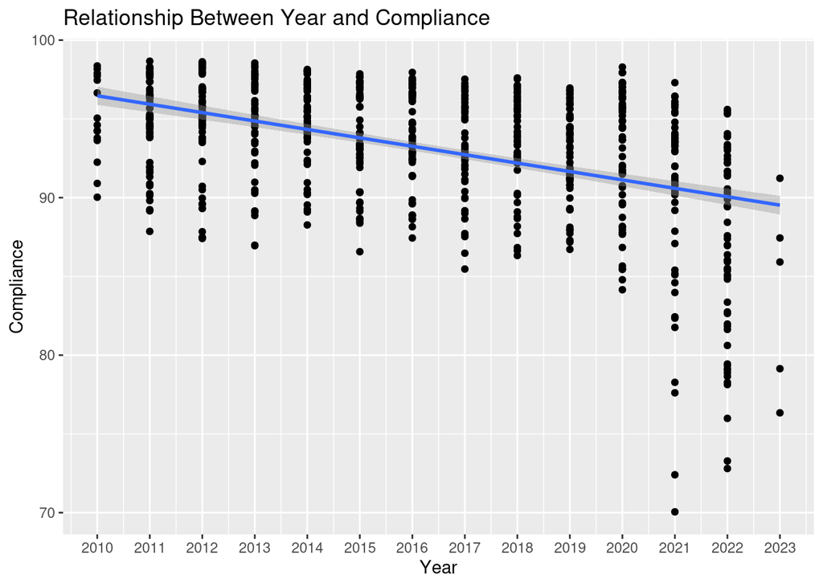

```r
#scatterplot of compliance percentage over the years
ggplot(incidents1, aes(x = Year, y = Compliance)) +
  geom_point()+
  geom_smooth(method = "lm") +
  scale_x_continuous(breaks = seq(2010,2023,1)) +
  labs(title = "Relationship Between Year and Compliance",
       x = "Year",
       fill = "Compliance (met or not)")
```

This visualization shows how the compliance percentage changes over the years. Over time, it seems that the spread of compliance seems to get larger, thus causing an average decrease over the years. As a result, there seems to be a negative trend between compliance and year which supports the negative correlation found in the correlation matrix.